# VAST15 Statistical Review

Paul Klemm

November 2015

This notebooks conducts a statistical analysis of hypotheses derived through the VAST’15 publication [3D Regression Heat Map Analysis of Population Study Data](http://dx.doi.org/10.1109/tvcg.2015.2468291).

Sources are:

- https://stats.stackexchange.com/questions/108007/correlations-with-categorical-variables
- http://www.analyticsforfun.com/2014/06/performing-anova-test-in-r-results-and.html
- https://stats.stackexchange.com/questions/12398/how-to-interpret-f-and-p-value-in-anova
- https://stats.stackexchange.com/questions/147863/how-to-interpret-the-residual-colors-on-a-mosaic-plot

## Setup

Load the data and only keep subjects with extracted centerlines. This is necessary to have a concurrent population with the paper.

```r
library(gplots)
library(jsonlite)
library(dplyr)
library(vcd)
library(gridExtra)
```

```r
ship <- read.csv('/Users/paul/Tresors/regresson-heatmap/data/breast_fat_imageonly_labels_parenchym_mean.csv')
```

## ANOVA of `Parenchyma Tissue` and `Kidney Disorder`

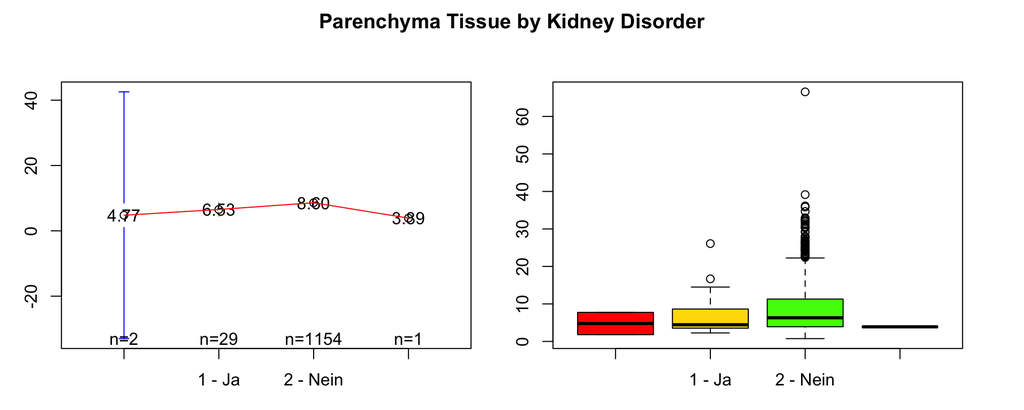

```r
par(mfrow=c(1,2), oma=c(1,1,2,1), mar=c(2,2,2,2))

plotmeans(ship$Segmentation_ParenchymToVolume ~ ship$Disease_Kidney_Disorder, digits=2, ccol="red", mean.labels=T, xlab="Kidney Disorder", ylab="Parenchyma Tissue")
boxplot(ship$Segmentation_ParenchymToVolume ~ ship$Disease_Kidney_Disorder, xlab="Kidney Disorder", ylab="parenchyma", col=rainbow(7))

title(main = "Parenchyma Tissue by Kidney Disorder", outer=TRUE)
```

Remove Subjects with error or no value for `kidney disorder`.

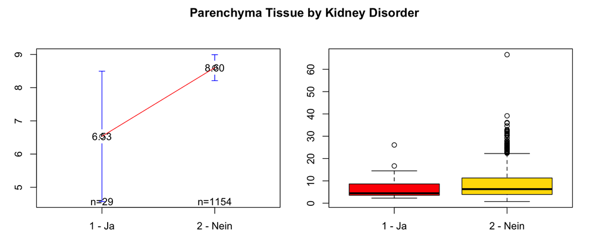

```r
# Analyze only for subjects with valid back pain indicators
ship_valid_kidney <- filter(ship, !(as.character(Disease_Kidney_Disorder)%in% c("99998 - Fehler, Daten nicht mehr erhebbar", "")))
ship_valid_kidney <- droplevels(ship_valid_kidney)

par(mfrow=c(1,2), oma=c(1,1,2,1), mar=c(2,2,2,2))
plotmeans(ship_valid_kidney$Segmentation_ParenchymToVolume ~ ship_valid_kidney$Disease_Kidney_Disorder, digits=2, ccol="red", mean.labels=T, xlab="kidney disorder", ylab="parenchyma tissue")

boxplot(ship_valid_kidney$Segmentation_ParenchymToVolume ~ ship_valid_kidney$Disease_Kidney_Disorder, xlab="kidney disorder", ylab="parenchyma", col=rainbow(7))
title(main = "Parenchyma Tissue by Kidney Disorder", outer=TRUE)
```

```r
summary(aov(formula = Segmentation_ParenchymToVolume~Disease_Kidney_Disorder, data = ship_valid_kidney))
```

```
##                           Df Sum Sq Mean Sq F value Pr(>F)
## Disease_Kidney_Disorder    1    121  121.02   2.663  0.103
## Residuals               1181  53681   45.45
```

The ANOVA comprises of a fairly low F value with a p value of 0.103. Therefore, by the standard of a p value of 0.05, the alternative hypothesis has to be rejected.

## ANOVA of `Parenchyma Tissue` and `Diabetes`

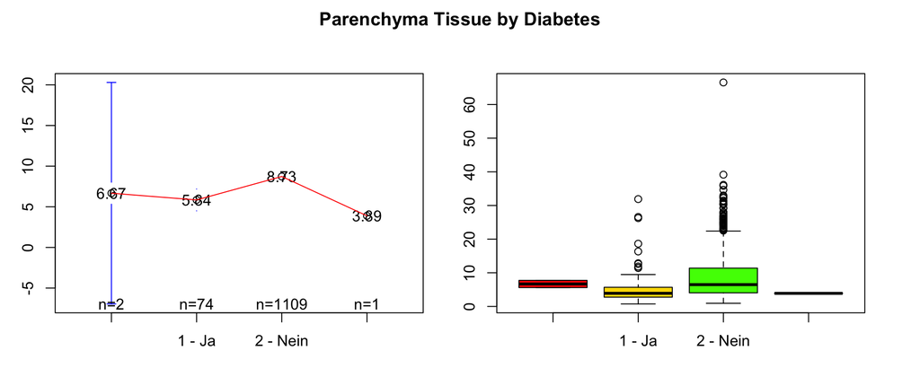

```r
par(mfrow=c(1,2), oma=c(1,1,2,1), mar=c(2,2,2,2))
plotmeans(ship$Segmentation_ParenchymToVolume ~ ship$Diabetes, digits=2, ccol="red", mean.labels=T, xlab="diabetes", ylab="parenchyma tissue")
boxplot(ship$Segmentation_ParenchymToVolume ~ ship$Diabetes, xlab="diabetes", ylab="parenchyma", col=rainbow(7))
title(main = "Parenchyma Tissue by Diabetes", outer=TRUE)
```

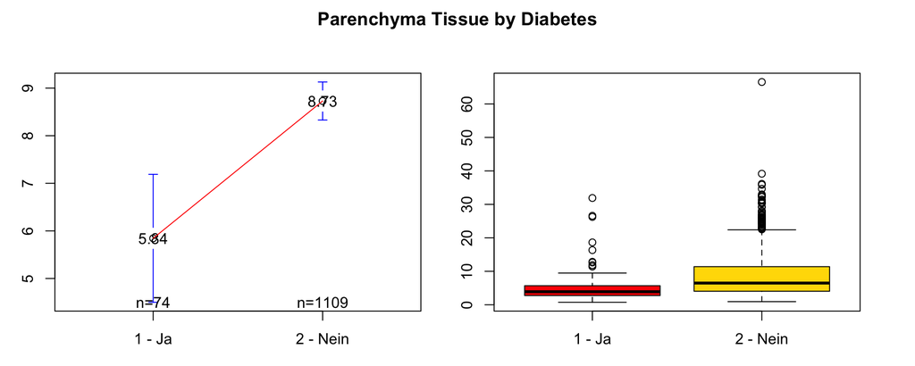

```r
# Filter the Error Values
ship_valid_diabetes <- filter(ship, !(as.character(Diabetes)%in% c("99998 - Fehler, Daten nicht mehr erhebbar", "")))
ship_valid_diabetes <- droplevels(ship_valid_diabetes)

# Create Means und Boxplots
par(mfrow=c(1,2), oma=c(1,1,2,1), mar=c(2,2,2,2))
plotmeans(ship_valid_diabetes$Segmentation_ParenchymToVolume ~ ship_valid_diabetes$Diabetes, digits=2, ccol="red", mean.labels=T, xlab="diabetes", ylab="parenchyma tissue")
boxplot(ship_valid_diabetes$Segmentation_ParenchymToVolume ~ ship_valid_diabetes$Diabetes, xlab="diabetes", ylab="parenchyma", col=rainbow(7))
title(main = "Parenchyma Tissue by Diabetes", outer=TRUE)
```

```r
# Calculate the Analysis of Variance
summary(aov(formula = Segmentation_ParenchymToVolume~Diabetes, data = ship_valid_diabetes))
```

```
##               Df Sum Sq Mean Sq F value   Pr(>F)
## Diabetes       1    577   577.3    12.8 0.000361 ***
## Residuals   1181  53262    45.1
## ---
## Signif. codes:  0 '***' 0.001 '**' 0.01 '*' 0.05 '.' 0.1 ' ' 1
```

Diabetes shows a significant correlation with parenchyma tissue with an F value of 12.8 and a p value of 0.0003.

## ANOVA of `Parenchyma Tissue` and `Hormone Replacement Therapy`

At first, visualize the means and draw the box plots.

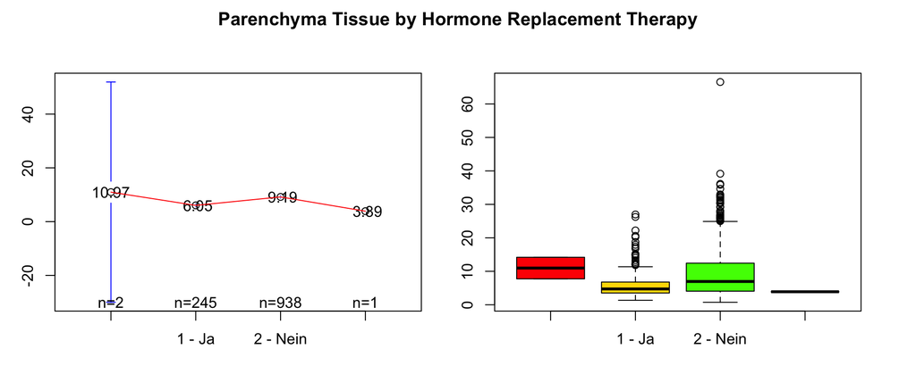

```r
# Create Means and Box Plot
par(mfrow=c(1,2), oma=c(1,1,2,1), mar=c(2,2,2,2))
plotmeans(ship$Segmentation_ParenchymToVolume ~ ship$Women_Hormone_Replacement_Therapy, digits=2, ccol="red", mean.labels=T, xlab="hormone replacement therapy", ylab="parenchyma tissue")
boxplot(ship$Segmentation_ParenchymToVolume ~ ship$Women_Hormone_Replacement_Therapy, xlab="hormone replacement therapy", ylab="parenchyma tissue", col=rainbow(7))
title(main = "Parenchyma Tissue by Hormone Replacement Therapy", outer=TRUE)
```

As before, remove the error dimensions and conduct the ANOVA.

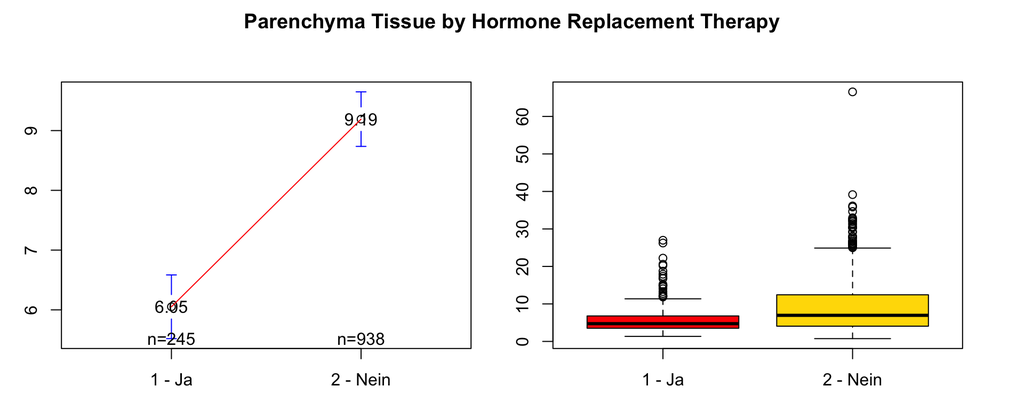

```r
# Filter the Error Values
ship_valid_hormone <- filter(ship, !(as.character(Women_Hormone_Replacement_Therapy)%in% c("99998 - Fehler, Daten nicht mehr erhebbar", "")))
ship_valid_hormone <- droplevels(ship_valid_hormone)

# Create the Means and the Box Plots
par(mfrow=c(1,2), oma=c(1,1,2,1), mar=c(2,2,2,2))
plotmeans(ship_valid_hormone$Segmentation_ParenchymToVolume ~ ship_valid_hormone$Women_Hormone_Replacement_Therapy, digits=2, ccol="red", mean.labels=T, xlab="hormone replacement therapy", ylab="parenchyma tissue")
boxplot(ship_valid_hormone$Segmentation_ParenchymToVolume ~ ship_valid_hormone$Women_Hormone_Replacement_Therapy, xlab="hormone replacement therapy", ylab="parenchyma tissue", col=rainbow(7))
title(main = "Parenchyma Tissue by Hormone Replacement Therapy", outer=TRUE)
```

```r
# Calculate the Analysis of Variance
summary(aov(formula = Segmentation_ParenchymToVolume~Women_Hormone_Replacement_Therapy, data = ship_valid_hormone))
```

```
##                                     Df Sum Sq Mean Sq F value   Pr(>F)
## Women_Hormone_Replacement_Therapy    1   1915  1915.1   43.58 6.14e-11 ***
## Residuals                         1181  51901    43.9
## ---
## Signif. codes:  0 '***' 0.001 '**' 0.01 '*' 0.05 '.' 0.1 ' ' 1
```

## ANOVA for `Parenchyma Tissue` and `Mammography Finding Classification`

The `mammography finding classification` feature is categorical and defined individual for both breasts. Therfore, the ANOVA is conducted for both the left and the right feature. At first, plot both features.

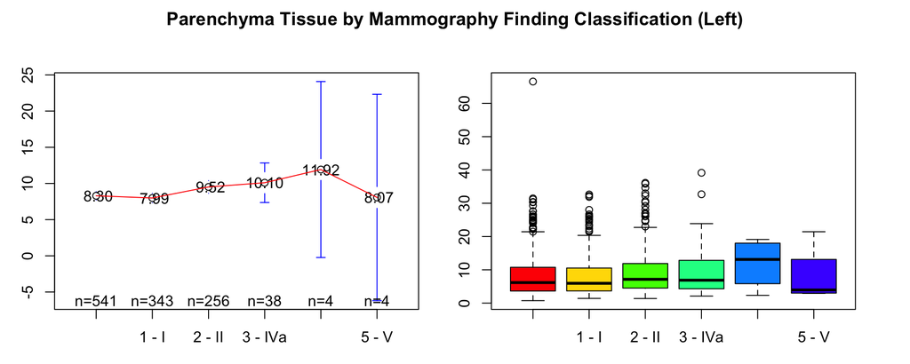

```r
par(mfrow=c(1,2), oma=c(1,1,2,1), mar=c(2,2,2,2))
plotmeans(ship$Segmentation_ParenchymToVolume ~ ship$Mammography_Left_BI_RADS, digits=2, ccol="red", mean.labels=T, xlab="Mammography Finding Classification (Left)", ylab="parenchyma tissue")
boxplot(ship$Segmentation_ParenchymToVolume ~ ship$Mammography_Left_BI_RADS, xlab="Mammography Finding Classification (Left)", ylab="parenchyma tissue", col=rainbow(7))
title(main = "Parenchyma Tissue by Mammography Finding Classification (Left)", outer=TRUE)
```

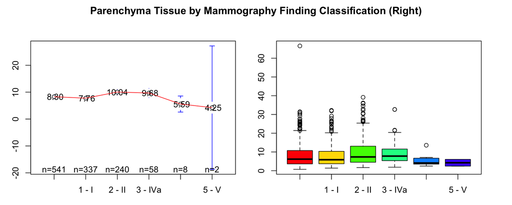

```r
par(mfrow=c(1,2), oma=c(1,1,2,1), mar=c(2,2,2,2))
plotmeans(ship$Segmentation_ParenchymToVolume ~ ship$Mammography_Right_BI_RADS, digits=2, ccol="red", mean.labels=T, xlab="Mammography Finding Classification (Right)", ylab="parenchyma tissue")
boxplot(ship$Segmentation_ParenchymToVolume ~ ship$Mammography_Right_BI_RADS, xlab="Mammography Finding Classification (Right)", ylab="parenchyma tissue", col=rainbow(7))
title(main = "Parenchyma Tissue by Mammography Finding Classification (Right)", outer=TRUE)
```

Now remove the invalid dimensions from both features and conduct the analysis.

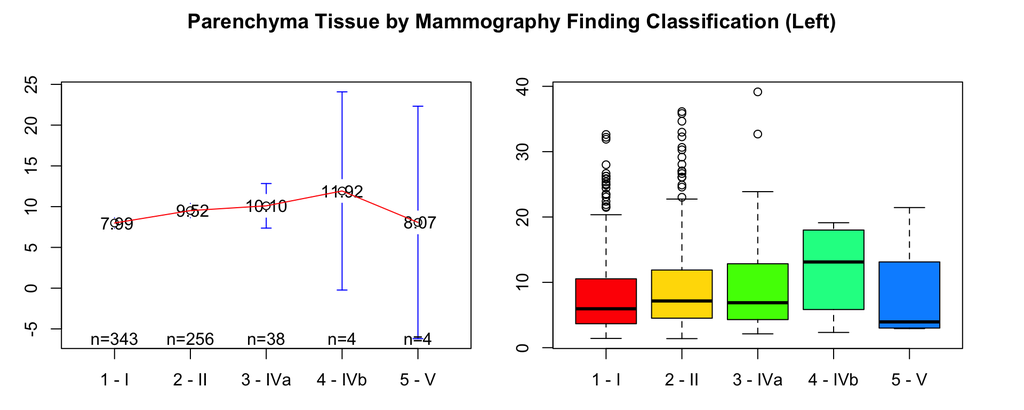

```r
# Filter Error Values
ship_valid_mammography <- filter(ship, !(as.character(Mammography_Right_BI_RADS)%in% c("99998 - Fehler, Daten nicht mehr erhebbar", "")))
ship_valid_mammography <- droplevels(ship_valid_mammography)

# Create Box and Means Plot (Left)
par(mfrow=c(1,2), oma=c(1,1,2,1), mar=c(2,2,2,2))
plotmeans(ship_valid_mammography$Segmentation_ParenchymToVolume ~ ship_valid_mammography$Mammography_Left_BI_RADS, digits=2, ccol="red", mean.labels=T, xlab="mammography finding classification (Left)", ylab="parenchyma tissue")
boxplot(ship_valid_mammography$Segmentation_ParenchymToVolume ~ ship_valid_mammography$Mammography_Left_BI_RADS, xlab="mammography finding classification (Left)", ylab="parenchyma tissue", col=rainbow(7))
title(main = "Parenchyma Tissue by Mammography Finding Classification (Left)", outer=TRUE)
```

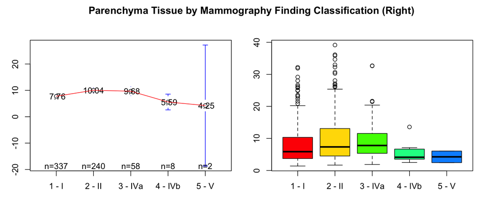

```r
# Create Box and Means Plot (Right)
par(mfrow=c(1,2), oma=c(1,1,2,1), mar=c(2,2,2,2))
plotmeans(ship_valid_mammography$Segmentation_ParenchymToVolume ~ ship_valid_mammography$Mammography_Right_BI_RADS, digits=2, ccol="red", mean.labels=T, xlab="mammography finding classification (Right)", ylab="parenchyma tissue")
boxplot(ship_valid_mammography$Segmentation_ParenchymToVolume ~ ship_valid_mammography$Mammography_Right_BI_RADS, xlab="mammography finding classification (Right)", ylab="parenchyma tissue", col=rainbow(7))
title(main = "Parenchyma Tissue by Mammography Finding Classification (Right)", outer=TRUE)
```

```r
# Calculate the Analysis of Variance
summary(aov(formula = Segmentation_ParenchymToVolume~Mammography_Left_BI_RADS, data = ship_valid_mammography))
```

```
##                           Df Sum Sq Mean Sq F value Pr(>F)
## Mammography_Left_BI_RADS   4    459  114.63   2.549 0.0383 *
## Residuals                640  28780   44.97
## ---
## Signif. codes:  0 '***' 0.001 '**' 0.01 '*' 0.05 '.' 0.1 ' ' 1
```

```r
summary(aov(formula = Segmentation_ParenchymToVolume~Mammography_Right_BI_RADS, data = ship_valid_mammography))
```

```
##                            Df Sum Sq Mean Sq F value   Pr(>F)
## Mammography_Right_BI_RADS   4    901  225.33   5.089 0.000484 ***
## Residuals                 640  28338   44.28
## ---
## Signif. codes:  0 '***' 0.001 '**' 0.01 '*' 0.05 '.' 0.1 ' ' 1
```

## ANOVA for `Parenchyma Tissue` and `Breast Lesions`

This is once again a categorical target feature which is derived for the left and right breast separately.

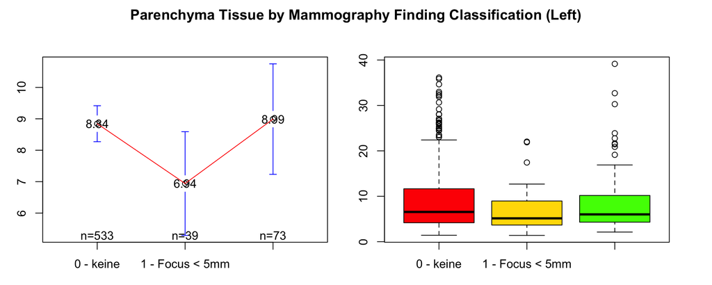

```r
# Create Means and Box Plots (Left)
par(mfrow=c(1,2), oma=c(1,1,2,1), mar=c(2,2,2,2))
plotmeans(ship_valid_mammography$Segmentation_ParenchymToVolume ~ ship_valid_mammography$Mammography_Left_Lesion, digits=2, ccol="red", mean.labels=T, xlab="mammography finding classification (Left)", ylab="parenchyma tissue")
boxplot(ship_valid_mammography$Segmentation_ParenchymToVolume ~ ship_valid_mammography$Mammography_Left_Lesion, xlab="mammography finding classification (Left)", ylab="parenchyma tissue", col=rainbow(7))
title(main = "Parenchyma Tissue by Mammography Finding Classification (Left)", outer=TRUE)
```

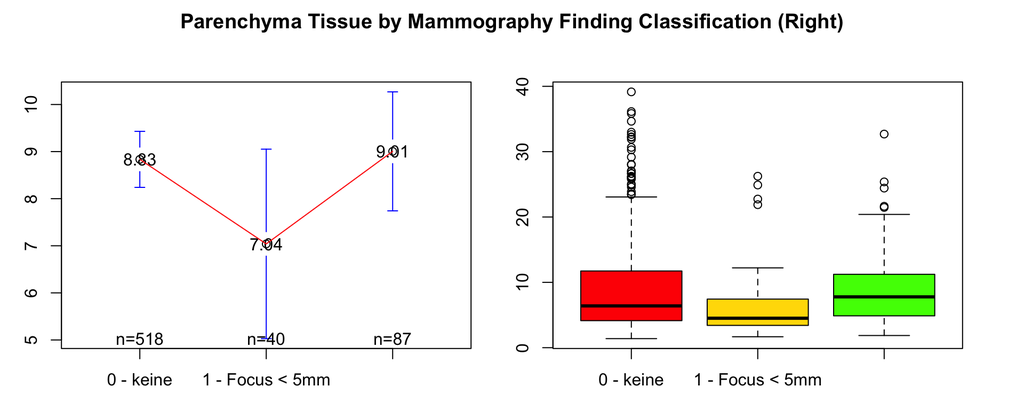

```r
# Create Means and Box Plots (Right)
par(mfrow=c(1,2), oma=c(1,1,2,1), mar=c(2,2,2,2))
plotmeans(ship_valid_mammography$Segmentation_ParenchymToVolume ~ ship_valid_mammography$Mammography_Right_Lesion, digits=2, ccol="red", mean.labels=T, xlab="mammography finding classification (Right)", ylab="parenchyma tissue")
boxplot(ship_valid_mammography$Segmentation_ParenchymToVolume ~ ship_valid_mammography$Mammography_Right_Lesion, xlab="mammography finding classification (Right)", ylab="parenchyma tissue", col=rainbow(7))
title(main = "Parenchyma Tissue by Mammography Finding Classification (Right)", outer=TRUE)
```

```r
# Calculate Analysis of Variance
summary(aov(formula = Segmentation_ParenchymToVolume~Mammography_Left_Lesion, data = ship_valid_mammography))
```

```
##                          Df Sum Sq Mean Sq F value Pr(>F)
## Mammography_Left_Lesion   2    137   68.36   1.508  0.222
## Residuals               642  29102   45.33
```

```r
summary(aov(formula = Segmentation_ParenchymToVolume~Mammography_Right_Lesion, data = ship_valid_mammography))
```

```
##                           Df Sum Sq Mean Sq F value Pr(>F)
## Mammography_Right_Lesion   2    126   63.18   1.393  0.249
## Residuals                642  29112   45.35
```

The ANOVA rejects the alternative hypothesis of a correlation between `parenchyma tissue` and `breast lesion`.

## ANOVA between `Parenchyma Tissue` and `Spiral Contraception`

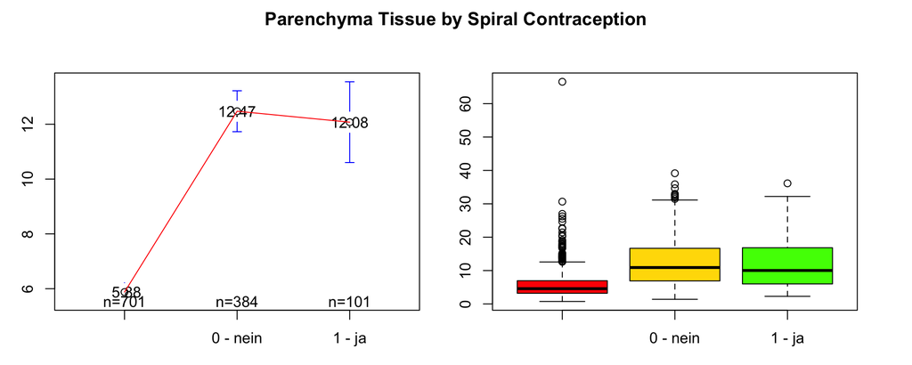

```r
# Create Means and Box Plots
par(mfrow=c(1,2), oma=c(1,1,2,1), mar=c(2,2,2,2))
plotmeans(ship$Segmentation_ParenchymToVolume ~ ship$MAMMA_Anamnesis_Contraception_Spiral, digits=2, ccol="red", mean.labels=T, xlab="spiral contraception", ylab="parenchyma tissue")
boxplot(ship$Segmentation_ParenchymToVolume ~ ship$MAMMA_Anamnesis_Contraception_Spiral, xlab="spiral contraception", ylab="parenchyma tissue", col=rainbow(7))
title(main = "Parenchyma Tissue by Spiral Contraception", outer=TRUE)
```

Now remove the subjects without a valid contraception entry.

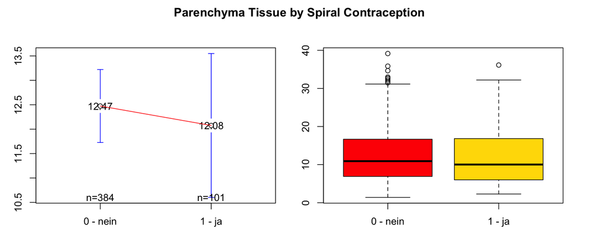

```r
# Drop the Error Values
ship_valid_contraception <- filter(ship, !(as.character(MAMMA_Anamnesis_Contraception_Spiral)%in% c("99998 - Fehler, Daten nicht mehr erhebbar", "")))
ship_valid_contraception <- droplevels(ship_valid_contraception)

# Calculate Means and Box Plot
par(mfrow=c(1,2), oma=c(1,1,2,1), mar=c(2,2,2,2))
plotmeans(ship_valid_contraception$Segmentation_ParenchymToVolume ~ ship_valid_contraception$MAMMA_Anamnesis_Contraception_Spiral, digits=2, ccol="red", mean.labels=T, xlab="spiral contraception", ylab="parenchyma tissue")
boxplot(ship_valid_contraception$Segmentation_ParenchymToVolume ~ ship_valid_contraception$MAMMA_Anamnesis_Contraception_Spiral, xlab="spiral contraception", ylab="parenchyma tissue", col=rainbow(7))
title(main = "Parenchyma Tissue by Spiral Contraception", outer=TRUE)
```

```r
# Calculate Analysis of Variance
summary(aov(formula = Segmentation_ParenchymToVolume~MAMMA_Anamnesis_Contraception_Spiral, data = ship_valid_contraception))
```

```
##                                       Df Sum Sq Mean Sq F value Pr(>F)
## MAMMA_Anamnesis_Contraception_Spiral   1     13   12.70   0.229  0.632
## Residuals                            483  26772   55.43
```